# Introdução à Regressão Linear

# Introdução

Este relatório trata da atividade denominada “Laboratório 05”, disponível no site do professor Jhames Sampaio[^1]. Resolvi fazer essas atividades para poder ter uma fluência básica em R, basicamente no tocante às funções dos pacotes básicos de estatística e de carregamento de bases de dados externas. Antes de fazer esse “minicurso”, eu já tinha feito um curso introdutório na Udemy, no qual aprendi os comandos básicos, carregamento de pacotes, tipos de dados, etc [^2].

## Carregamento dos pacotes necessários

```r
library(ggplot2)
library(dplyr)
# library(plyr)
library(htmltools)
library(knitr)
library(rmarkdown)
library(kableExtra) #Para gerar tabelas com um layout agradável
```

# Preparação

O filme Moneyball aborda a “busca pelo segredo do sucesso no beisebol”. O filme conta a história de um time de baixo orçamento, o Oakland Athletics, que acreditava que estatísticas pouco utilizadas, tal como a habilidade de um jogador chegar a uma base, prediziam melhor a habilidade de marcar pontos do que estatísticas mais comuns, como **home** **runs**, **RBIs** (runs batted in, pontos feitos quando um jogador estava rebatendo), e média de rebatidas. Contratar jogadores que se destacavam nessas estatísticas pouco utilizadas se mostrou muito mais econômico para o time.

Neste laboratório iremos explorar os dados de todos os 30 times da Liga Principal de Beisebol dos Estados Unidos e examinaremos a relação linear entre pontos marcados numa temporada e várias outras estatísticas dos jogadores. Nosso objetivo será resumir essas relações de maneira visual e numérica para identificar qual variável, se houver alguma, melhor nos ajuda a predizer os pontos marcados por um time numa temporada.

## Os dados

Vamos carregar os dados da temporada de 2011[^3]:

```r
load(file = "mlb11.Rdata")
```

Além dos pontos marcados (`runs`), este conjunto de dados contém sete variáveis tradicionalmente utilizadas: vez ao taco (`at_bats`), rebatidas (`hits`), rebatidas para fora do campo (`homeruns`), média de rebatidas (`bat_avg`), eliminações (`strikeouts`), bases roubadas (`stolen_bases`), e vitórias (`wins`). Também foram incluídas três novas variáveis: percentual de alcance de base (`new_onbase`), percentual de potência (`new_slug`), e alcance de base mais potência (`new_obs`). Para a primeira parte da análise consideraremos as sete variáveis tradicionais. Ao final do laboratório, você trabalhará com as novas variáveis por conta própria.

> Que tipo de gráfico você utilizaria para mostrar a relação entre `runs` e alguma outra variável numérica? Crie um gráfico dessa relação utilizando a variável `at_bats` como preditora. A relação parece ser linear? Se você soubesse o valor de `at_bats` de um time, você se sentiria confiante para utilizar um modelo linear para predizer o número de runs?

Para ter uma ideia da relação entre as duas variáveis, podemos usar um gráfico de pontos ou dispersão:

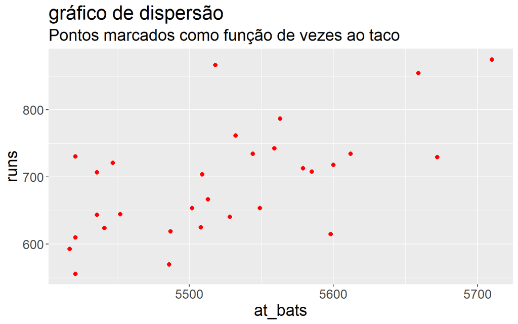

```r
  ggplot(data = mlb11, aes(x = at_bats, y = runs)) +
  geom_point(size = 2, color = "red") +
  labs(
    title = "gráfico de dispersão",
    subtitle = "Pontos marcados como função de vezes ao taco"
  ) +
  theme(text = element_text(size = 18))
```

Apesar da expressiva dispersão dos dados, é possível perceber, a partir do gráfico de pontos mostrado, que existe uma tendência de crescimento linear direto do número de pontos marcados (`runs`) com o número de vezes ao taco (`at_bats`). Portanto, dado um modelo linear devidamente ajustado aos dados por meio de algum algoritmo adequado de otimização (como mínimos quadrados ordinários, por exemplo), poderíamos sim utilizar esse modelo linear para predizer o número de pontos marcados por um time na temporada, usando a variável `at_bats` como preditora.

Se a relação parece ser linear, podemos quantificar a força da relação utilizando o coeficiente de correlação.

```r
mlb11 %>%
  summarise(cor(runs, at_bats))
```

```
##   cor(runs, at_bats)
## 1           0.610627
```

# Soma dos quadrados dos resíduos

> Nesta seção você irá utilizar uma função interativa, `plot_ss`, para investigar o que queremos dizer com “soma dos quadrados dos resíduos”. Você deverá rodar esta função em seu console, não no documento markdown. Para rodar esta função é necessário que o conjunto de dados `mlb11` esteja carregado em seu ambiente de trabalho.

Assim como utilizamos a média e o desvio padrão para resumir características importantes de uma única variável, podemos resumir a relação entre essas duas variáveis por meio de uma reta que melhor descreve sua associação. Utilize a seguinte função interativa para selecionar a linha que você acha que cruza a nuvem de pontos da melhor maneira.

```r
plot_ss(x = mlb11$at_bats, y = mlb11$runs, showSquares = T)
```

Depois de executar esse comando, você será solicitado a clicar em dois pontos situados no gráfico para definir uma reta. Depois que você fizer isso, a reta que você especificou será mostrada na cor preta e os resíduos na cor azul. Perceba que há 30 resíduos, um para cada uma das 30 observações. Lembre-se que os resíduos são a diferença entre os valores observados e os valores preditos pela linha:

$$e_i = y_i - \hat{y_i}$$
A maneira mais comum de se fazer uma regressão linear é selecionar a linha que minimiza a soma dos quadrados dos resíduos. Para visualizar o quadrado dos resíduos, você pode rodar novamente o comando de geração do gráfico e adicionar o argumento showSquares = `TRUE`.

```r
plot_ss(x = mlb11$at_bats, y = mlb11$runs, showSquares = T)
```

Note que o resultado da função `plot_ss` fornece a inclinação (coeficiente angular) e o intercepto da sua reta, bem como a soma dos quadrados.

# O modelo linear

É bastante cansativo tentar obter a linha dos mínimos quadrados, ou seja, a reta que minimiza a soma dos quadrados dos resíduos, por meio de tentativa e erro. Ao invés disso, podemos utilizar a função `lm` no R para ajustar o modelo linear (também conhecido como linha de regressão).

```r
m1 = lm(formula = runs ~ at_bats, data = mlb11)
```

O primeiro argumento da função lm é a fórmula, descrita como `y ~ x`. O que a função faz é obter o modelo linear de `runs` (pontos marcados) em função de `at_bats` (vezes ao taco). Aqui, cabe um destaque para o operador `~` (tilde), que é usado para separar as variáveis dependentes e independentes em um modelo. Neste caso, a fórmula diz: *`runs` depende de `at_bats`*. O segundo argumento especifica que o R deve buscar no banco de dados `mlb11` as variáveis `runs` e `at_bats`.

A saída da função `lm` é um objeto que contém todas as informações que precisamos sobre o modelo linear que acabamos de ajustar. Podemos acessar essa informação utilizando a função `summary`.

```r
summary(m1)
```

```
##
## Call:
## lm(formula = runs ~ at_bats, data = mlb11)
##
## Residuals:
##     Min      1Q  Median      3Q     Max
## -125.58  -47.05  -16.59   54.40  176.87
##
## Coefficients:
##               Estimate Std. Error t value Pr(>|t|)
## (Intercept) -2789.2429   853.6957  -3.267 0.002871 **
## at_bats         0.6305     0.1545   4.080 0.000339 ***
## ---
## Signif. codes:  0 '***' 0.001 '**' 0.01 '*' 0.05 '.' 0.1 ' ' 1
##
## Residual standard error: 66.47 on 28 degrees of freedom
## Multiple R-squared:  0.3729, Adjusted R-squared:  0.3505
## F-statistic: 16.65 on 1 and 28 DF,  p-value: 0.0003388
```

Vamos analisar o resultado passo a passo. Primeiramente, a fórmula utilizada para descrever o modelo é apresentada no começo. Depois da fórmula você verá o resumo de cinco números dos resíduos. A tabela “Coefficients” (coeficientes) apresentada em seguida é fundamental; sua primeira coluna apresenta o intercepto-y do modelo linear e o coeficiente da variável `at_bats`. Com essa tabela, podemos descrever a reta de regressão de mínimos quadrados para o modelo linear:

$$\hat{y_i} = -2789.2429 + 0.6305 \times
at\_bats$$
Uma última informação que abordaremos sobre a saída da função `summary` é o “Multiple R-Squared” (R-quadrado Múltiplo), ou de maneira abreviada, $R^2$. O valor do $R^2$ representa a proporção de variabilidade na variável resposta que é explicada pela variável explicativa. Neste modelo, 37,3% da variabilidade dos pontos `runs` é explicada pelas vezes ao taco `at_bats`.

> Ajuste um novo modelo que utilize a variável `homeruns` para predizer `runs`. Utilizando as estimativas dos resultados do R, escreva a equação da reta de regressão. O que a inclinação (coeficiente angular) nos diz sobre a relação entre o sucesso de um time e seus home runs?

```r
m2 = lm(formula = runs ~ homeruns, data = mlb11)
summary(m2)
```

```
##
## Call:
## lm(formula = runs ~ homeruns, data = mlb11)
##
## Residuals:
##     Min      1Q  Median      3Q     Max
## -91.615 -33.410   3.231  24.292 104.631
##
## Coefficients:
##             Estimate Std. Error t value Pr(>|t|)
## (Intercept) 415.2389    41.6779   9.963 1.04e-10 ***
## homeruns      1.8345     0.2677   6.854 1.90e-07 ***
## ---
## Signif. codes:  0 '***' 0.001 '**' 0.01 '*' 0.05 '.' 0.1 ' ' 1
##
## Residual standard error: 51.29 on 28 degrees of freedom
## Multiple R-squared:  0.6266, Adjusted R-squared:  0.6132
## F-statistic: 46.98 on 1 and 28 DF,  p-value: 1.9e-07
```

Nesse caso, ajustando um modelo linear que utiliza a variável `homeruns` para predizer a variável `runs`, obtemos a seguinte equação para a reta de regressão:

$$\hat{y_i} = 415.2389 + 1.8345 \times
homeruns$$
Ainda, o coeficiente angular nos diz que o número de pontos marcados (`runs`) cresce com o número de rebatidas fora do campo (`homeruns`) a uma taxa de 1,8345 vezes.

Para visualizarmos melhor a relação entre as duas variáveis, podemos plotar um gráfico de pontos:

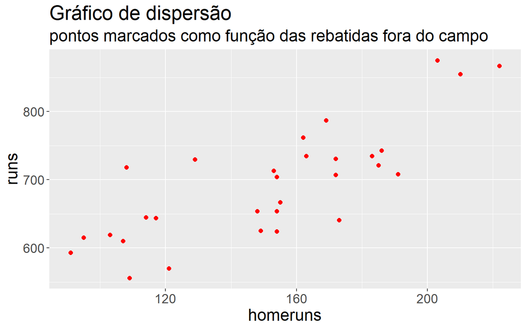

```r
ggplot(data = mlb11, aes(x = homeruns, y = runs)) +
  geom_point(size = 2, col = "red") +
  labs(
    title = "Gráfico de dispersão",
    subtitle = "pontos marcados como função das rebatidas fora do campo"
  ) +
  theme(text = element_text(size = 18))
```

Além disso, podemos ver também o coeficiente de correlação entre as variáveis `runs` e `homeruns`:

```r
mlb11 %>%
  summarise(coef_cor = cor(runs, homeruns))
```

```
##    coef_cor
## 1 0.7915577
```

# Predição e erro de predição

Vamos criar um gráfico de dispersão com a reta de mínimos quadrados para `m1` disposta junto aos pontos.

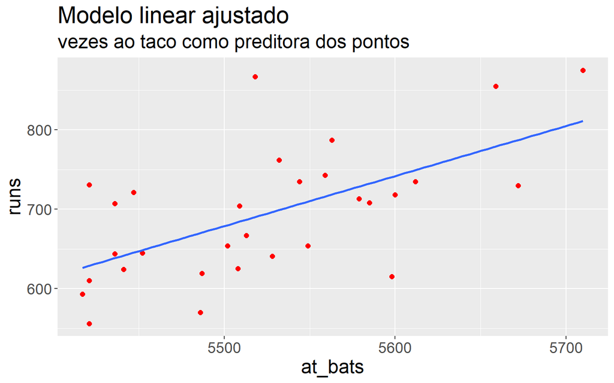

```r
ggplot(data = mlb11, aes(x = at_bats, y = runs)) +
  geom_point(size = 2, col = "red") +
  stat_smooth(method = "lm", formula = y ~ x, se = F) +
  labs(
    title = "Modelo linear ajustado",
    subtitle = "vezes ao taco como preditora dos pontos"
  ) +
  theme(text = element_text(size = 18))
```

Aqui nós estamos literalmente adicionando uma camada ao topo de nosso gráfico. A função `stat_smooth` cria uma reta ao ajustar um modelo linear. Ela também pode nos mostrar o erro padrão `se` associado à nossa reta, mas iremos omitir essa saída por enquanto.

Esta linha pode ser utilizada para predizer $y$ em função do valor $x$. Quando as previsões associadas aos valores de $x$ são feitas além dos valores observados, nos referimos a elas como extrapolações e não é bem recomendado. Portanto, previsões realizadas à partir dos dados observados são mais confiáveis. Ela também é utilizada para computar os resíduos.

> Se o gerente de um time visse a reta de regressão de mínimos quadrados e não os dados reais, quantos pontos (`runs`) ele prediria para um time com 5.579 vezes ao taco (`at_bats`)? Esse valor superestima ou subestima o valor real, e por quanto? Em outras palavras, qual é o resíduo para esta predição?

Utilizando os valores dos parâmetros ajustados de acordo com a amostra, $\beta_0 = −2789.2429$ e $\beta_1 = 0.6305$, além da equação do nosso modelo de regressão ajustado, podemos escrever:

```r
p_marcados = as.double(subset(mlb11, at_bats == 5579, select = "runs"))

p_previstos = -2789.2429 + 0.6305*5579

cat(
  "Pontos previstos: ",
  p_previstos,
  "\nPontos marcados: ",
  p_marcados,
  "\nResíduo: ",
  p_marcados - p_previstos,
  "\nErro relativo absoluto: ",
  abs((p_marcados - p_previstos)/p_marcados),
  "\n"
  )
```

```
## Pontos previstos:  728.3166
## Pontos marcados:  713
## Resíduo:  -15.3166
## Erro relativo absoluto:  0.02148191
```

Escrita alternativa para o trecho acima:

```r
p_marcados = mlb11 %>%
  filter(at_bats == 5579) %>%
  select(runs) %>%
  as.double()

p_previstos = -2789.2429 + 0.6305*5579

cat(
  "Pontos previstos: ",
  p_previstos,
  "\nPontos marcados: ",
  p_marcados,
  "\nResíduo: ",
  p_marcados - p_previstos,
  "\nErro relativo absoluto: ",
  abs((p_marcados - p_previstos)/p_marcados),
  "\n"
  )
```

Conforme podemos ver na saída da linha de código acima, o número de pontos previsto pelo modelo em função do número de vezes ao taco, para o caso em que `at_bats = 5579`, é igual a 728, ao passo que o número de pontos observados para esse número de vezes ao taco é 713. Vemos, portanto, que o modelo superestima um pouco o valor realmente observado. Vemos também que a diferença relativa entre os dois valores é de cerca de 2%.

# Diagnóstico do Modelo

Para avaliar se um modelo linear é confiável, precisamos verificar (1) a linearidade, (2) resíduos normalmente distribuídos, e (3) variância constante.

**Linearidade**: Você já verificou se a relação entre pontos (`runs`) e vezes ao taco (`at_bats`) é linear utilizando o gráfico de dispersão. Deveríamos também verificar essa condição utilizando um gráfico dos resíduos em função dos valores ajustados.

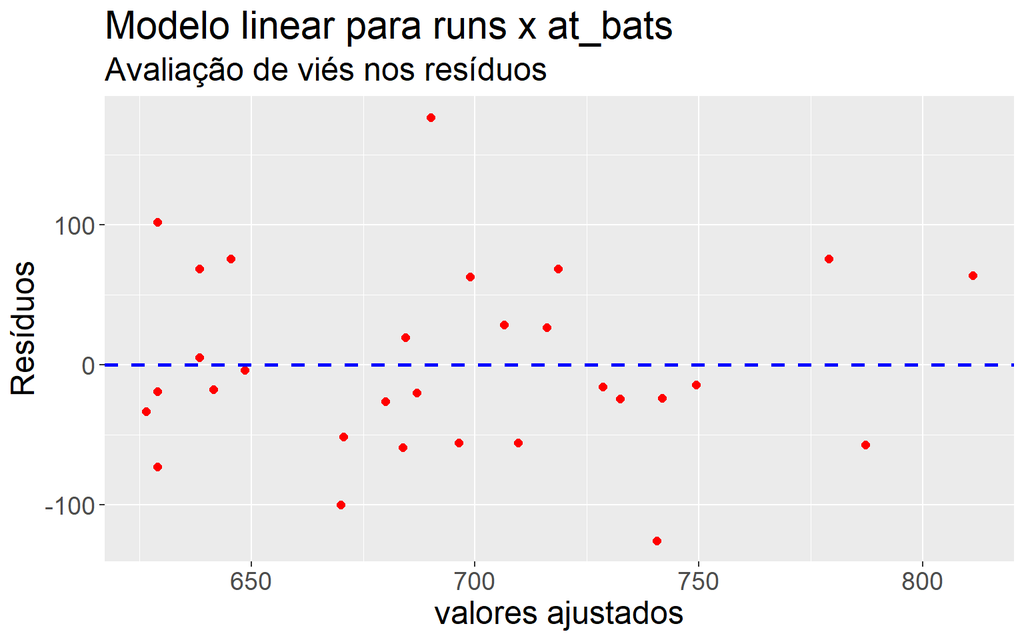

```r
ggplot(data = m1, aes(x = .fitted, y = .resid)) +
  geom_point(col = "red", size = 2) +
  geom_hline(yintercept = 0, linetype = "dashed", linewidth = 1, col = "blue") +
  labs(
    x = "valores ajustados",
    y = "Resíduos",
    title = "Modelo linear para runs x at_bats",
    subtitle = "Avaliação de viés nos resíduos"
  ) +
  theme(text = element_text(size = 18))
```

Note que o nosso objeto `m1` também funciona como um conjunto de dados, pois nele estão armazenados os valores ajustados ($\hat{y}$) e os resíduos. Observe tembém que nós utilizamos um código bem elegante aqui: depois de criar o gráfico de dispersão na primeira camada (primeira linha de código), nós adicionamos uma linha tracejada em $y=0$ (para nos ajudar a checar se os resíduos estão distribuiídos em torno de 0), e também nomeamos os eixos de modo a tornar o gráfico mais informativo.

> Há algum padrão aparente no gráfico de resíduos? O que isso indica sobre a linearidade da relação entre pontos (`runs`) e vezes ao taco (`at_bats`)?

Conforme podemos ver no gráfico de resíduos plotado, não há um padrão aparente (viés) na dispersão dos dados. Aparentemente, os resíduos estão dispostos aleatoriamente em torno de zero, o que é uma suposição incial em modelos de regressão. Contudo, a baixa quantidade de pontos dificulta um pouco a análise, já que alguns dos pontos estão muito afastados da reta tracejada.

**Resíduos aproximadamente normais**: Para verificar essa condição, podemos conferir o histograma dos resíduos:

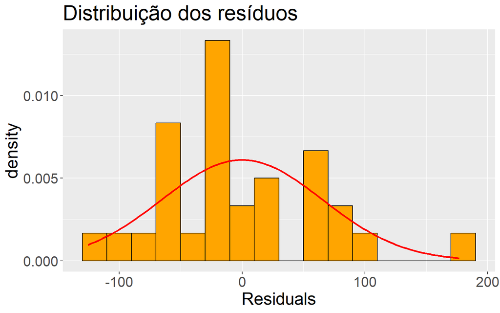

```r
ggplot(data = m1, aes(x = .resid)) +
  geom_histogram(
    aes(y = after_stat(density)),
    binwidth = 20,
    col = "black",
    fill = "orange"
    ) +
  stat_function(
    fun = dnorm,
    args =
      list(mean = mean(m1$residuals), sd = sd(m1$residuals)),
    col = "red",
    linewidth = 1
  ) +
  labs(
    x = "Residuals",
    title = "Distribuição dos resíduos"
  ) +
  theme(text = element_text(size = 20))
```

ou um QxQ-plot (quantis dos resíduos vs quantis teóricos da normal padrão). Nesse caso, esperamos que se os quantis seguirem a mesma distribuição (normal) eles devem estar posicionados sobre uma reta com orientação positiva.

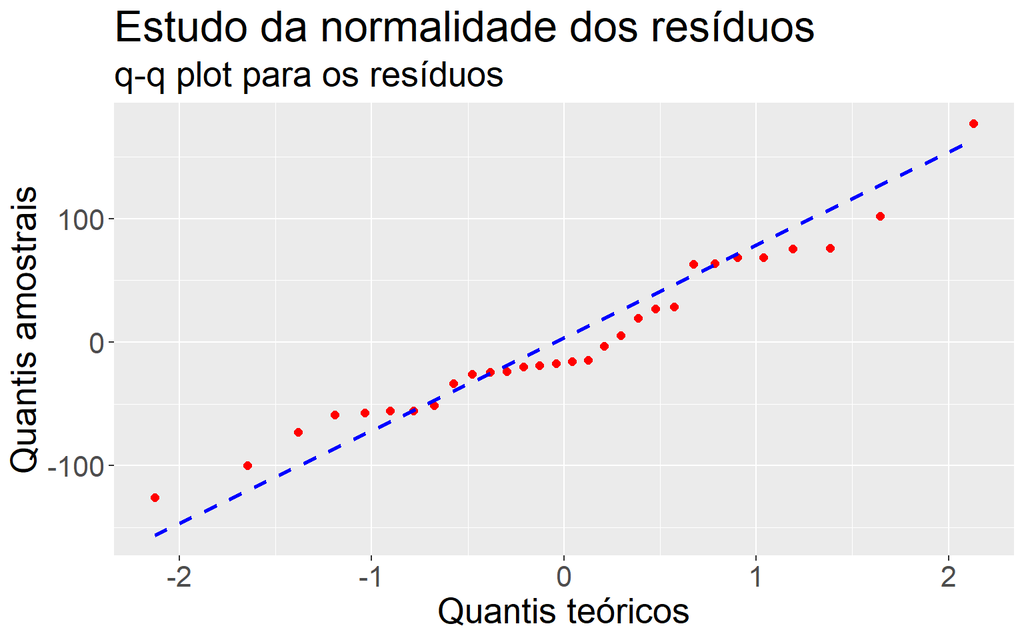

```r
ggplot(data = m1, aes(sample = .resid)) +
  geom_qq(col = "red", size = 2) +
  geom_qq_line(linetype = "dashed", color = "blue", linewidth = 1) +
  labs(
    x = "Quantis teóricos",
    y = "Quantis amostrais",
    title = "Estudo da normalidade dos resíduos",
    subtitle = "q-q plot para os resíduos"
  ) +
  theme(text = element_text(size = 20))
```

Note que a sintaxe para a construção deste gráfico é um pouco diferente do que você está aconstumado: nós indicamos `sample` para os resíduos aos invés de `x` (pois os dados provém de uma amostra, ou sample em inglês), e indicamos também o método estatístico `geom_qq()`, que significa “quantil-quantil” (QxQ), outro nome bem comum para este tipo de gráfico.

**Variância constante**: Essa condição pode ser verificada através da curva dos resíduos padronizados em função dos valores ajustados. Aqui, é importante ressaltar que essa condição também é conhecida como *homocedasticidade*.

Para verificar se um modelo de regressão linear ajustado atende aos pressupostos, podemos aplicar a função `plot()` à saída de `lm()`. Para entendermos qual será o resultado, podemos rodar o comando `?plot.lm`.

- A função `par()` é usada para definir parâmetros de gráficos
- O argumento `mfrow` divide o gráfico conforme uma matriz $n_r \times c_c$, plotando primeiro os quadros horizontais.
- A função `plot()`, quando aplicada a um objeto do tipo `lm()`, dispõe de 6 saídas:

1 - gráfico de dispersão para resíduos contra valores ajustados

2 - gráfico de localização da escala da raíz dos resíduos versus valores ajustados

3 - q-q plot para a distribuição normal

4 - gráfico de distâncias de Cook versus rótulos de linha

5 - resíduos versus alavancagem

6 - distâncias de Cook versus alavancagem

Por padrão, a saída apresenta as 3 primeiras e a quinta opções. Porém, outras podem ser selecionadas com o argumento `which`.

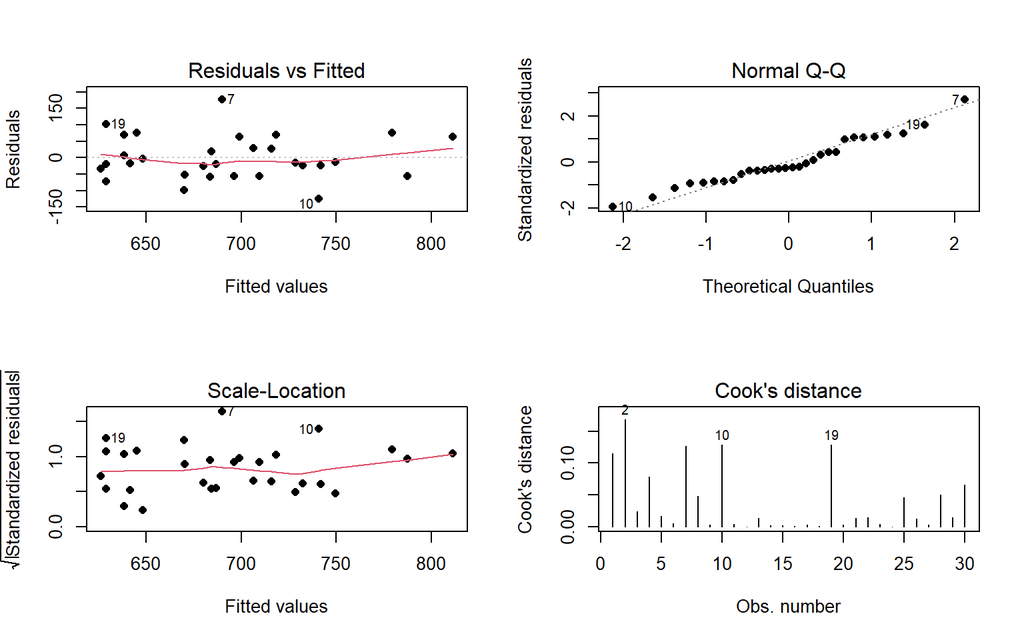

```r
par(mfrow = c(2, 2))
plot(m1, which = c(1:4), pch = 16)
```

Olhando para o terceiro quadro acima, vemos que a hipótese de homocedasticidade aproximada dos resíduos está verificada.